# Entregable

Miguel Ángel Castaño Ibáñez

4/10/2021

## Librerías

Cargo todas las librerías utlilizadas para para este ejercicio

```r
suppressPackageStartupMessages({
  library(dplyr)          # Manipulacion de datos
  library(data.table)     # Leer y procesar ultra-rapido
  library(ggplot2)        # La librería grafica
  library(inspectdf)      # EDAs automaticos
  library(ranger)         # Fast randomForest
  library(forcats)        # Tratar variables categoricas
  library(tictoc)         # Calcular tiempos
  library(missRanger)     # Fast imputation of NAs --- Finalmente no se usa
  library(lubridate)      # Tratar formato fecha
  library(Hmisc)          # para hacer el describe
})
```

## Lectura ficheros

Cargamos los ficheros donde están el conjunto de entrenamiento y el de test, ademas de tener un dataset solo el id y la variable objetivo

```r
dattrainOr    <- fread(file = "./data/train.csv", data.table = FALSE )
dattrainLabOr <- fread(file = "./data/train_labels.csv", data.table = FALSE )
dattestOr     <- fread(file = "./data/test.csv", data.table = FALSE  )
```

## EDA (Exploratory Data Analysis)

A continuación, mostraremos una serie de graficas que tendran como objetivo ayudarnos para un primer analisis de nuestro dataset y empezar a tratarlo para finalmente obtener nuestro modelo de predicción.

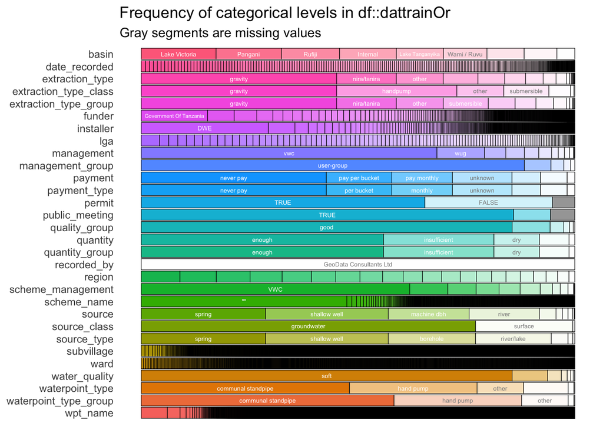

```r
### inspectdf

# Horizontal bar plot for categorical column composition
x <- inspect_cat(dattrainOr)
show_plot(x)
```

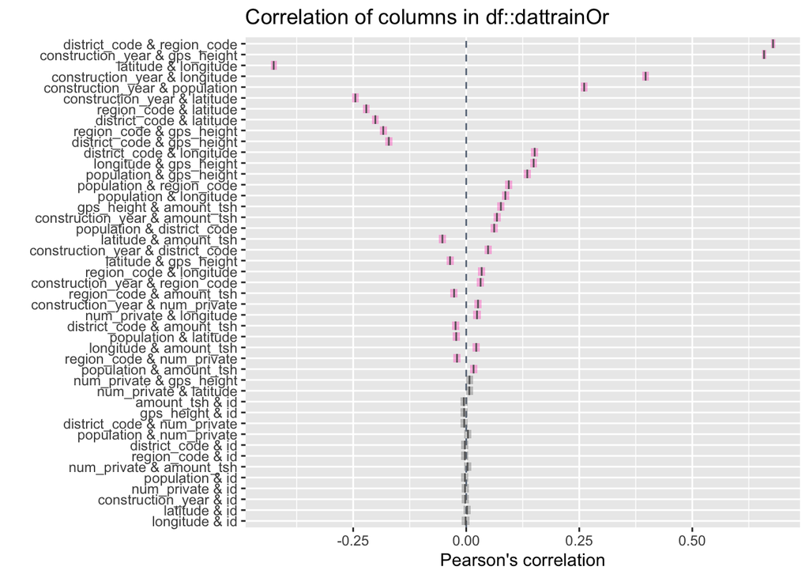

```r
# Correlation betwee numeric columns + confidence intervals
x <- inspect_cor(dattrainOr)
show_plot(x)
```

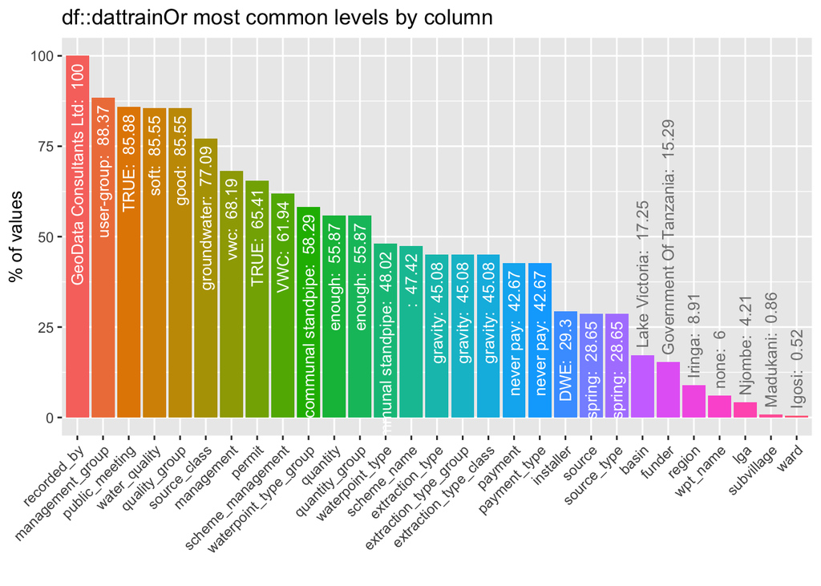

```r
# Bar plot of most frequent category for each categorical column
x <- inspect_imb(dattrainOr)
show_plot(x)
```

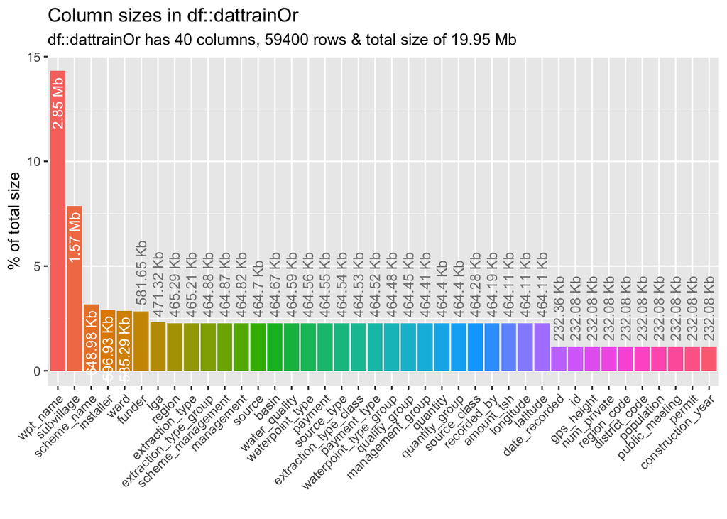

```r
# Bar plot showing memory usage for each column
x <- inspect_mem(dattrainOr)
show_plot(x)
```

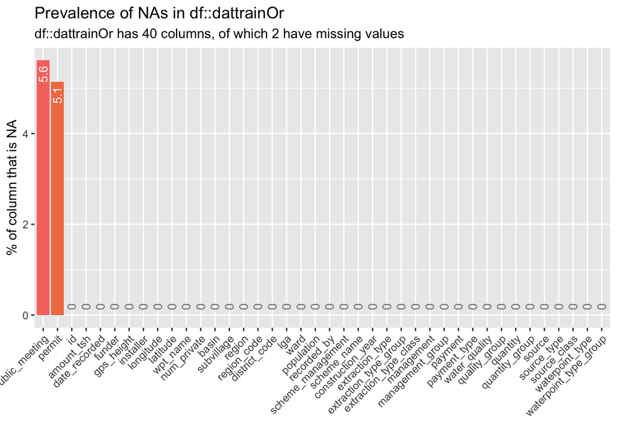

```r
# Occurence of NAs in each column ranked in descending order
x <- inspect_na(dattrainOr)
show_plot(x)
```

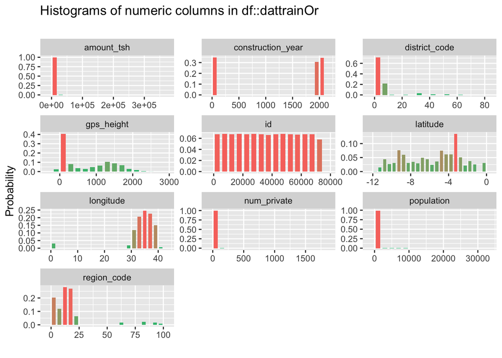

```r
# Histograms for numeric columns
x <- inspect_num(dattrainOr)
show_plot(x)
```

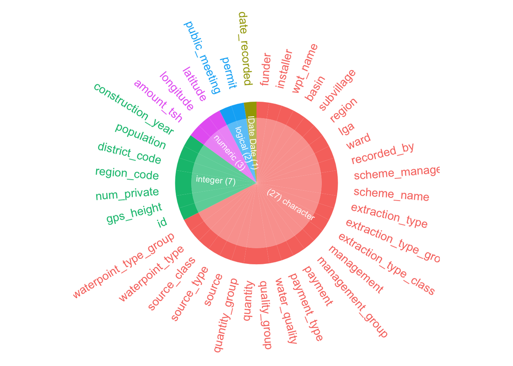

```r
# Barplot of column types
x <- inspect_types(dattrainOr)
show_plot(x)
```

### Tratamiento de datos

Para tratar los datos vamos a juntar los dos conjuntos (train y test) en un dataset y operar con ellos

```r
data <- merge(dattrainOr, dattestOr, all = T, sort = F)
```

### Variables categoricas

Vamos a revisar las variables categoricas, y descartar la que tiene valor contante (recorded_by) y por otro lado aquellas con demasiado valores diferentes (<3000). He considerado este número, ya que creo que el founder, instaler y scheme_name puede ser importante para el modelo, mientras que para las dos ultimas obtiene valores demasiado elevados, superiores a 20 mil.

```r
# char
datcat_df <- data %>% select(where(is.character))

# calculamos valores posibles de cada categorica
numlev_df <- data.frame()
for (i in 1:ncol(datcat_df)) {
  col_tmp <- datcat_df[, i]
  num_lev <- length(unique(col_tmp))
  numlev_df[i, 1] <- names(datcat_df)[i]
  numlev_df[i, 2] <- num_lev
  # print(numlev_df)
}
names(numlev_df) <- c('vars', 'levels')
numlev_df %>% arrange(levels)
```

```
##                     vars levels
## 1            recorded_by      1
## 2           source_class      3
## 3       management_group      5
## 4               quantity      5
## 5         quantity_group      5
## 6          quality_group      6
## 7  waterpoint_type_group      6
## 8  extraction_type_class      7
## 9                payment      7
## 10          payment_type      7
## 11           source_type      7
## 12       waterpoint_type      7
## 13         water_quality      8
## 14                 basin      9
## 15                source     10
## 16            management     12
## 17     scheme_management     13
## 18 extraction_type_group     13
## 19       extraction_type     18
## 20                region     21
## 21                   lga    125
## 22                  ward   2098
## 23                funder   2141
## 24             installer   2411
## 25           scheme_name   2869
## 26            subvillage  21426
## 27              wpt_name  45684
```

```r
# descartamos < 300
vars_gd <- numlev_df %>%
  filter(levels < 3000, levels > 1) %>%
  select(vars)
datcat_gd <- datcat_df[ , vars_gd$vars]
```

### Categoricas, numericas y booleanas

Juntaremos las variables categoricas, booleanas y numericas en nuestro conjunto, además añadiremos las variable date_recorded

```r
# num
datnum_df <- data %>% select(where(is.numeric))
# merge
datnumcat_df <- cbind(datnum_df, datcat_gd)

# add bool
datnumcat_df$permit <- data$permit
datnumcat_df$public_meeting <- data$public_meeting

# add date_recorded
datnumcat_df$date_recorded <- data$date_recorded
```

### Variables iguales

Vamos a tratar de eliminar las variables que podrian ser iguales. En mi caso yo he decidido quitar solamente quantity_group, ya que pese a que payment y payment_type tienen muchas columnas similares este ejercicio trata de obtener la prediccion mas acertada y no se centra en el numero de variables y tiempo de computo, porlo tanto estas nos pueden aportar algo de información

```r
#--- quantity y quantity_group  - Iguales
unique(datnumcat_df$quantity)
```

```
## [1] "enough"       "insufficient" "dry"          "seasonal"     "unknown"
```

```r
unique(datnumcat_df$quantity_group)
```

```
## [1] "enough"       "insufficient" "dry"          "seasonal"     "unknown"
```

```r
all.equal(datnumcat_df$quantity, datnumcat_df$quantity_group)
```

```
## [1] TRUE
```

```r
# #--- payment y payment_type  - Iguales # modelo 7
# unique(datnumcat_df$payment)
# unique(datnumcat_df$payment_type)
# all.equal(datnumcat_df$payment, datnumcat_df$payment_type)
# head(datnumcat_df[, c('payment', 'payment_type')])


#elimino payment_type y quantity_group
datnumcat_df$quantity_group <- NULL
# datnumcat_df$payment_type <- NULL


# No los estraigo (modelo 6)

#--- management  - Iguales
# unique(datnumcat_df$management)
# unique(datnumcat_df$management_group)

# #--- extraction_type  - Iguales
# unique(datnumcat_df$extraction_type)
# unique(datnumcat_df$extraction_type_group)
# unique(datnumcat_df$extraction_type_class)
# all.equal(datnumcat_df$extraction_type, datnumcat_df$extraction_type_group)
#
# datnumcat_df$management_group <- NULL
#
# datnumcat_df$extraction_type <- NULL
# datnumcat_df$extraction_type_group <- NULL
```

### Imputamos datos

Imputamos los valores missing (NAs) con missRanger, estos seran:

- construction_year == 0, ya que son valores anomalos, y posiblemente se trate de observaciones donde no se han registrado su fecha
- longitude = 0 (en nuestro caso he puesto menor de 10 por si quedaba algun valor irregular). Teniendo en cuenta que las bombas estan aproimadamente en una coordenada cercanas a 30, ya que perteneceran al mismo territorio, por lo tanto tienen que ser valores cercanos y con una distribucion normal.
- gps_height == 0 o negativo, ya que considero que para zonas donde esten iguales mas bajas que el nivel del mar quizas no sea necesario una bomba y por tanto puede ser un error

```r
# construction_year ( == 0 -> NAs)
datnumcat_df$fe_construction_year <- datnumcat_df$construction_year
datnumcat_df$fe_construction_year <- ifelse(
  datnumcat_df$fe_construction_year == 0,
  NA,
  datnumcat_df$fe_construction_year
)

# longitude (< 10 -> NAs)
datnumcat_df$fe_longitude <- datnumcat_df$longitude
datnumcat_df$fe_longitude <- ifelse(
  datnumcat_df$fe_longitude < 10,
  NA,
  datnumcat_df$fe_longitude
)

# gps_height ( Negativos -> NAs)
datnumcat_df$fe_gps_height <- datnumcat_df$gps_height
datnumcat_df$fe_gps_height <- ifelse(
  datnumcat_df$fe_gps_height < 1,
  NA,
  datnumcat_df$fe_longitude
)

# quito las variables imputadas
# no eliminamos todavia para FEATURE
# datnumcat_df$longitude <- NULL
# datnumcat_df$construction_year <- NULL
# datnumcat_df$gps_height <- NULL

# missRanger
datnumcat_df <- missRanger(
  datnumcat_df,
  pmm.k = 3,
  num.trees = 100
)
```

```
##
## Missing value imputation by random forests
##
##   Variables to impute:       permit, public_meeting, fe_construction_year, fe_longitude, fe_gps_height
##   Variables used to impute:  id, amount_tsh, gps_height, longitude, latitude, num_private, region_code, district_code, population, construction_year, funder, installer, basin, region, lga, ward, scheme_management, scheme_name, extraction_type, extraction_type_group, extraction_type_class, managem…
## iter 1:  .....
## iter 2:  .....
## iter 3:  .....
```

## Feature engineering

El siguiente paso es formar variables en base a las que ya tenemos, por ello antes de eliminar todas las variables imputadas anteriores he decidido tratar de obtener nuevas variables

Esta primera se trata de la diferencia del tiempo, en días, que ha tardado desde que se recogió el dato hasta la última observación.

```r
# data_recorded
datnumcat_df$fe_date_recorded <- as.numeric(as.Date('2013-12-03') - as.Date(data$date_recorded))
```

Aquí obtenemos la los años que hace que fue construida, tomando como referencia el años siguiente a la ultima construida

```r
# age
datnumcat_df$fe_age <- 2014 - datnumcat_df$construction_year
```

```r
# distancia al ecuador
datnumcat_df$fe_dist <- sqrt( datnumcat_df$fe_longitude^2 + datnumcat_df$latitude^2)
```

Por último, he decidido obtener la frecuencia de las variables categoricas más importantes, para hecho he combertid oel dataframe en un datatable para operar con el más rapidamente y su posterior reconversion a dataframe

```r
# fecuencia de las variables categoricas mas importantes
# to datatable
datnumcat_dt <- as.data.table(datnumcat_df)
# add
datnumcat_dt[ , fe_funder                 := .N , by =  funder ]
datnumcat_dt[ ,  fe_quantity              := .N , by =  quantity]
datnumcat_dt[ ,  fe_extraction_type_class := .N , by =  extraction_type_class]
datnumcat_dt[ ,  fe_payment               := .N , by =  payment]
datnumcat_dt[ ,  fe_source                := .N , by =  source]
datnumcat_dt[ ,  fe_extraction_type_group := .N , by =  extraction_type_group]
datnumcat_dt[ ,  fe_extraction_type       := .N , by =  extraction_type]
datnumcat_dt[ ,  fe_region                := .N , by =  region]
datnumcat_dt[ ,  fe_lga                   := .N , by =  lga]
datnumcat_dt[ ,  fe_ward                  := .N , by =  ward]
datnumcat_dt[ ,  fe_scheme_name           := .N , by =  scheme_name]
# datnumcat_dt[ ,  fe_recorded_by           := .N , by = recorded_by]
# datnumcat_dt[ ,  fe_source_class          := .N , by = source_class]
# datnumcat_dt[ ,  fe_management_group      := .N , by =  management_group]
# datnumcat_dt[ ,  fe_quantity_group        := .N , by =  quantity_group]
# datnumcat_dt[ ,  fe_quality_group         := .N , by =  quality_group]
# datnumcat_dt[ ,  fe_waterpoint_type_group := .N , by =  waterpoint_type_group]
# datnumcat_dt[ ,  fe_payment_type          := .N , by =  payment_type]
# datnumcat_dt[ ,  fe_source_type           := .N , by =  source_type]
# datnumcat_dt[ ,  fe_waterpoint_type       := .N , by =  waterpoint_type]
# datnumcat_dt[ ,  fe_water_quality         := .N , by =  water_quality ]
# datnumcat_dt[ ,  fe_basin                 := .N , by =  basin]
# datnumcat_dt[ ,  fe_management            := .N , by =  management]
# datnumcat_dt[ ,  fe_scheme_management     := .N , by =  scheme_management]
# datnumcat_dt[ ,  fe_installer             := .N , by =  installer]
# datnumcat_dt[ ,  fe_subvillage            := .N , by =  subvillage]
# datnumcat_dt[ ,  fe_wpt_name              := .N , by =  wpt_name]
# to dataframe
datnumcat_df <- as.data.frame(datnumcat_dt)
# No elimino las variables originales, debido a la su importancia
```

Una vez creadas las nuevas variables es hora de borrar las variables imputadas y generar nuestro modelo.

```r
# elimino las variables imputadas
datnumcat_df$longitude <- NULL
datnumcat_df$construction_year <- NULL
datnumcat_df$gps_height <- NULL
```

## MODELO

El siguiente paso es separar, ya con de dataset tratado, los conjuntos train y test.

Obtenemos el punto de corte, para dividir nuestro dataset y mergeamos la variable objetivo al conjunto de entrenamiento.

```r
## Separamos datos train y test
# length train
length(dattrainOr[,1])
```

```
## [1] 59400
```

```r
# length test
length(dattestOr[,1])
```

```
## [1] 14850
```

```r
# length both joined
length(datnumcat_df[,1])
```

```
## [1] 74250
```

```r
# cut
length(datnumcat_df[,1])-length(datnumcat_df[,1])
```

```
## [1] 0
```

```r
# Separamos los conjuntos train y test
dattrainOr_imp <- datnumcat_df[1:59400,]
dattestOr_imp <- datnumcat_df[59401:74250,]


## Variable objetivo
# merge del id
dattrainOrLab_obj_imp <- merge(
  dattrainOr_imp, dattrainLabOr,
  by.x = c('id'), by.y = c('id'),
  sort = FALSE
)

## status_group as factor para el random forest
dattrainOrLab_obj_imp$status_group <- as.factor(dattrainOrLab_obj_imp$status_group)
```

Genero el modelo con el algoritmo random forest, que tras aplicar un Grid Search decidí para los paramentros mtry y num.trees, 5 y 600 respectivamente.

Aplico la funcion proporcionada por el paquete ranger para obtener mi modelo.

```r
## Genero el model
tic()
my_model <- ranger(
  status_group ~ . ,
  importance = 'impurity',
  num.trees = 600,
  mtry = 5,
  data = dattrainOrLab_obj_imp,
  seed = 67583
)
toc()
```

```
## 84.437 sec elapsed
```

El acierto esperado lo podemos calcular restandole a 1 el error estimado que es según randomforest de:

```r
# acierto_estimado -> 1 - error_estimado
acierto <- 1 - my_model$prediction.error
acierto
```

```
## [1] 0.8182997
```

Para finalizar antes de generar la predicción con el conjunto test vamos a pintar la importancia de las variables para generar nuestro modelo

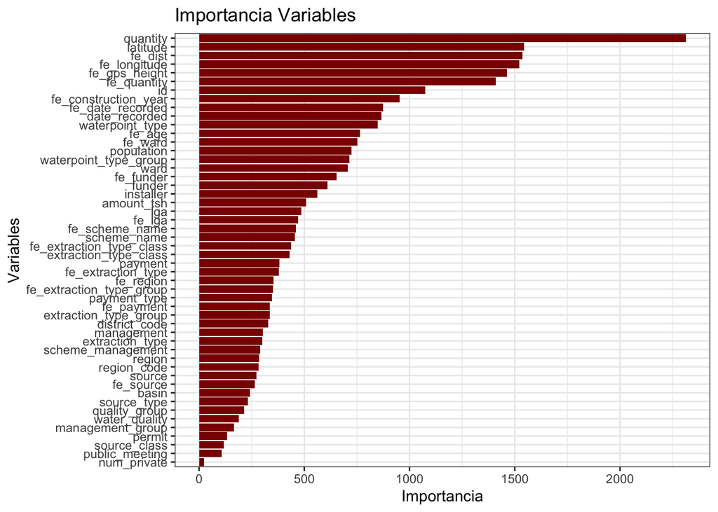

```r
### Pintar importancia de variables
## obtengo  importancia
impor_df <- as.data.frame(my_model$variable.importance)
names(impor_df)[1] <- c('Importance')
impor_df$vars <- rownames(impor_df)
# borro los ids(variables ya copiadas en columna)
rownames(impor_df) <- NULL
## pinto la importancia
ggplot(impor_df, aes(fct_reorder(vars, Importance), Importance)) +
  geom_col(group = 1, fill = "darkred") +
  coord_flip() +
  labs(x = 'Variables', y = 'Importancia', title = 'Importancia Variables') +
  theme_bw()
```

## Predicciones

Aplico la funcion predict para posteriormente guardar ese dataset en un fichero .csv y su posteriror subida a la plataforma: https://www.drivendata.org/competitions/7/pump-it-up-data-mining-the-water-table/

```r
## get prediction
my_pred <- predict(my_model, dattestOr_imp)

## file for submission
my_sub <- data.table(
  id = dattestOr_imp$id,
  status_group = my_pred$predictions
)

## save submission
fwrite(my_sub, file = "./submissions/sub_entregable_final.csv" )
```

En este trozo de texto a continuacion podemos ver las predicciones de todos los modelos generados, tanto el acierto estimado segun ranger como el resultado final una ves subido los datos drivendata. A continuacion se señalaran los ajustes hechos en cada modelo

```r
## my_models
#       ranger      drivendata
# 1 - 0.8175421   -   0.8165   - <3000 cat, bool
# 2 - 0.8191582   -   0.8219   - imputar los restantes menos gps_height
# 3 - 0.8188384   -   0.8246   - imputar tambien gps_height
# 4 - 0.8189394   -   0.8244   - freq de todas la categoricas
# 5 - 0.8186027   -   0.8249   - quito las categoricas no isada
# 6 - 0.8173232   -   0.8242   - quito otras iguales
# 7 - 0.8179630   -   0.8257   - back to 5 y añado payment_type (casi repetida)
# 8 - 0.8182997   -   0.8256   -  for para ver cual num_trees y mtry es mejor

# MODELO GANADOR -> 7
```

## Conclusiones

Finalmente decido quedarme con el modelo 7 como modelo ganador, aun que condero que se podrian ganar algunas centesimas o incluso decimas tratando de cambiar la semilla (seed). Con todo hesto no he considerado mejorar mi modelo por que 0.8257 es un numero bastante elevado acercandose al record de 0.8290. A demás, tambien considero que es un resultado bastante satisfactorio que podria llegar a producción.

Otras alternativas a este algoritmo podria haber sido utilizar la libreria h20 vista en clase, peor ho he optado por ranger ya que me pare muy buena herramienta, sencilla y obtiene un valor vastante cercano al record anteriormente mencionado.